# Draft Strategy Guide

What the SGP model says about how to win in the Moonlight Graham League

Published

March 24, 2026

# The Fundamental Economics

Before talking about specific strategies, it’s worth understanding the basic economics that govern this league. Every strategic principle below flows from these numbers.

## What Is a Standings Point Worth?

In rotisserie, you earn points by finishing higher in each of the 10 categories. The team that finishes first in a category gets 10 points; last place gets 1. Over five seasons, the average champion scored **88.5 total points** and the average last-place team scored **24.5** — a spread of 64 points. That means roughly **6-7 standings points** separate each position in the final standings.

Because each category is worth the same number of standings points, the model values every category equally. One standings point gained in stolen bases is worth exactly the same as one standings point gained in strikeouts. But the *cost* of gaining a standings point differs wildly across categories — and that’s where the strategy lives.

## The Price of a Standings Point

The SGP denominator for each category tells you how many raw stat units it takes to gain one standings point. A smaller denominator means the stat is “easier to move” — each raw unit has more impact on the standings.

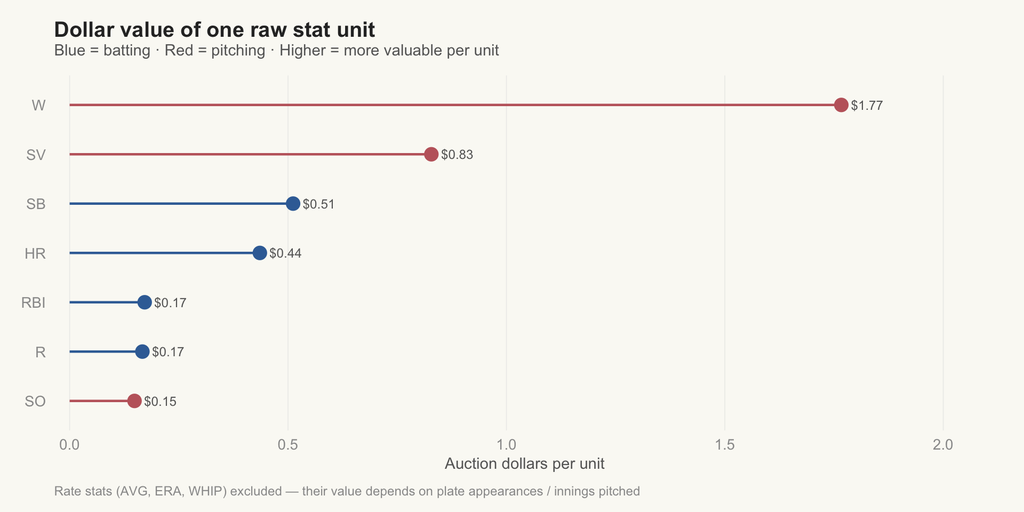

```r
denoms <- tibble(
  category = c("R", "HR", "RBI", "SB", "AVG", "W", "SV", "SO", "ERA", "WHIP"),
  denom = c(31.82, 12.17, 30.85, 10.36, 0.00306, 3.00, 6.40, 35.68, 0.101, 0.0186),
  side = c(rep("Batting", 5), rep("Pitching", 5)),
  # Dollar value of one raw unit (using avg ~$5.30/PAR)
  dollar_per_unit = c(
    5.3 / 31.82,  # R
    5.3 / 12.17,  # HR
    5.3 / 30.85,  # RBI
    5.3 / 10.36,  # SB
    NA,            # AVG (rate stat)
    5.3 / 3.00,   # W
    5.3 / 6.40,   # SV
    5.3 / 35.68,  # SO
    NA,            # ERA (rate stat)
    NA             # WHIP (rate stat)
  )
)

denoms |>
  filter(!is.na(dollar_per_unit)) |>
  ggplot(aes(x = dollar_per_unit, y = fct_reorder(category, dollar_per_unit),
             color = side)) +
  geom_segment(aes(x = 0, xend = dollar_per_unit,
                   yend = fct_reorder(category, dollar_per_unit)),
               linewidth = 0.8) +
  geom_point(size = 4) +
  geom_text(aes(label = paste0("$", sprintf("%.2f", dollar_per_unit))),
            hjust = -0.3, size = 3.2, color = pal$mid) +
  scale_color_manual(values = c("Batting" = pal$primary, "Pitching" = pal$secondary)) +
  scale_x_continuous(expand = expansion(mult = c(0.02, 0.2))) +
  labs(
    title = "Dollar value of one raw stat unit",
    subtitle = "Blue = batting · Red = pitching · Higher = more valuable per unit",
    x = "Auction dollars per unit", y = NULL,
    caption = "Rate stats (AVG, ERA, WHIP) excluded — their value depends on plate appearances / innings pitched"
  ) +
  h_grid
```

**Wins are the most valuable single counting stat in the league at $1.77 each.** The denominator is only 3.0 — meaning just 3 additional wins can move you up one standings position. This is why ace starters who consistently win 15+ games are so valuable: they’re generating 5+ standings points from wins alone.

**Saves ($0.83 each) and stolen bases ($0.51)** are the next most valuable per unit. Both have small denominators (6.4 and 10.4 respectively), meaning each unit carries outsized standings impact. A closer who saves 30 games generates ~4.7 SGP from that single category.

**Home runs ($0.44)** are worth more than twice as much per unit as runs ($0.17), RBIs ($0.17), or strikeouts ($0.15). This is because the denominator for HR is 12.2 vs. 31.8 for R and 30.8 for RBI. A player who hits 10 extra home runs gains nearly a full standings point; a player who scores 10 extra runs gains about a third of one.

## Each Category Is an Equal Slice of the Pie

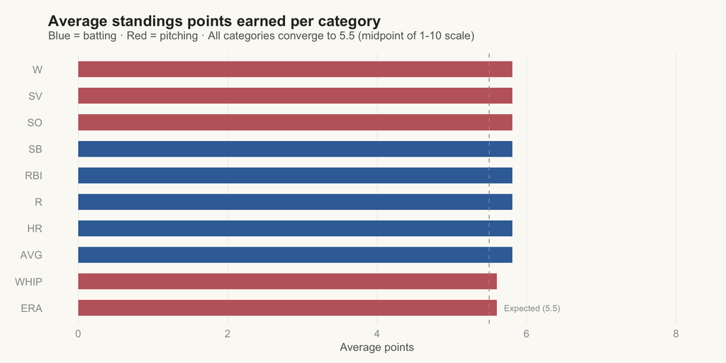

```r
# Standings point variance per category — they're all equal
pts_cols <- c("R_pts", "HR_pts", "RBI_pts", "SB_pts", "AVG_pts",
              "W_pts", "SV_pts", "ERA_pts", "WHIP_pts", "SO_pts")

avg_pts <- standings |>
  summarise(across(all_of(pts_cols), mean)) |>
  pivot_longer(everything(), names_to = "category", values_to = "avg_pts") |>
  mutate(
    category = str_remove(category, "_pts"),
    side = if_else(category %in% c("R", "HR", "RBI", "SB", "AVG"), "Batting", "Pitching")
  )

avg_pts |>
  ggplot(aes(x = avg_pts, y = fct_reorder(category, avg_pts), fill = side)) +
  geom_col(width = 0.6) +
  geom_vline(xintercept = 5.5, linetype = "dashed", color = pal$light, linewidth = 0.4) +
  annotate("text", x = 5.7, y = 1, label = "Expected (5.5)", color = pal$light,
           size = 3, hjust = 0) +
  scale_fill_manual(values = c("Batting" = pal$primary, "Pitching" = pal$secondary)) +
  scale_x_continuous(limits = c(0, 8)) +
  labs(
    title = "Average standings points earned per category",
    subtitle = "Blue = batting · Red = pitching · All categories converge to 5.5 (midpoint of 1-10 scale)",
    x = "Average points", y = NULL
  ) +
  h_grid
```

# Principle 1: Balanced Rosters Beat Top-Heavy Ones

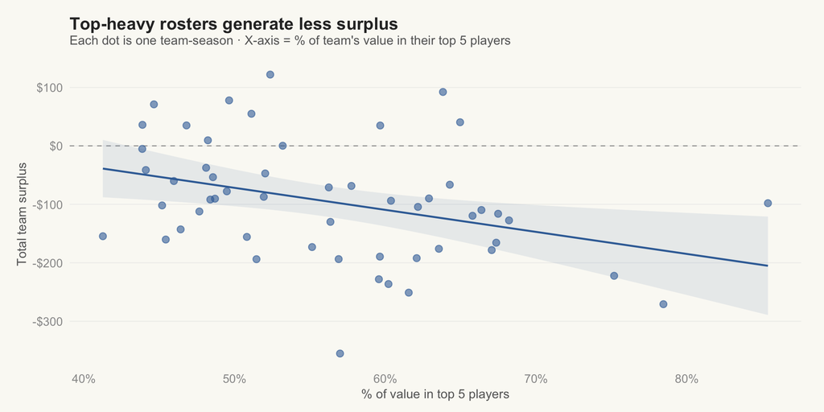

```r
# Team roster concentration vs surplus
team_conc <- all_val |>
  filter(auction_value > 0) |>
  group_by(fantasy_team, year) |>
  summarise(
    total_val = sum(auction_value),
    top5_val = sum(sort(auction_value, decreasing = TRUE)[1:min(5, n())]),
    .groups = "drop"
  ) |>
  mutate(top5_pct = top5_val / total_val * 100)

team_surplus <- all_val |>
  filter(!is.na(surplus)) |>
  group_by(fantasy_team, year) |>
  summarise(total_surplus = sum(surplus), .groups = "drop")

roster_shape <- team_conc |>
  inner_join(team_surplus, by = c("fantasy_team", "year"))

roster_shape |>
  ggplot(aes(x = top5_pct, y = total_surplus)) +
  geom_hline(yintercept = 0, linetype = "dashed", color = pal$light, linewidth = 0.4) +
  geom_smooth(method = "lm", se = TRUE, color = pal$primary, fill = pal$primary,
              alpha = 0.1, linewidth = 0.8) +
  geom_point(color = pal$primary, alpha = 0.6, size = 2.5) +
  scale_x_continuous(labels = label_percent(scale = 1)) +
  scale_y_continuous(labels = dollar_format(prefix = "$")) +
  labs(
    title = "Top-heavy rosters generate less surplus",
    subtitle = "Each dot is one team-season · X-axis = % of team's value in their top 5 players",
    x = "% of value in top 5 players", y = "Total team surplus"
  )
```

There’s a clear negative relationship (r = -0.36): **teams that concentrate their value in a handful of stars tend to have worse overall surplus**. The most balanced rosters (top-5 players accounting for ~47% of value) average about -$50 in surplus, while the most top-heavy (top-5 at ~67% of value) average -$125.

Why? In rotisserie, there’s no playoff — you’re scored across all 10 categories simultaneously. A team with one $80 hitter and nine $1 hitters will dominate HR but get crushed in every other category. Spreading your budget across more productive players covers more categories. The star who costs $50 but produces $60 of value generates $10 of surplus; the $5 player who produces $15 generates $10 too — but doesn’t blow up your ability to fill other positions.

**The draft implication:** resist the temptation to bid $60+ on a single superstar unless you’re confident you can fill the rest of your roster cheaply. The data says you’re better off with three $30 players than one $70 player and two $15 players.

# Principle 2: SS and 3B Are Systematically Undervalued

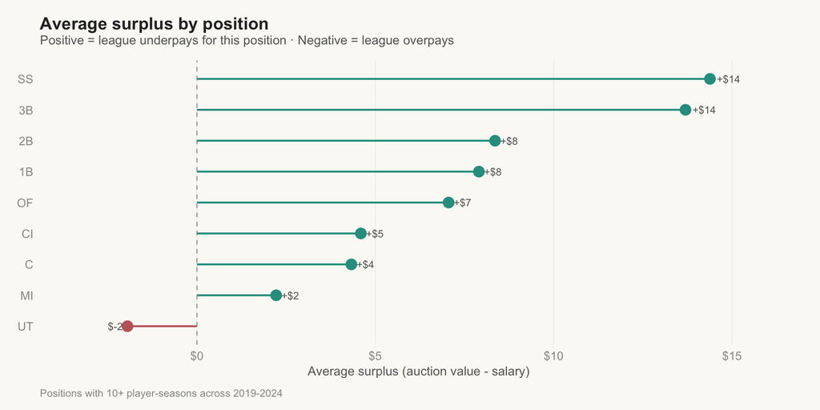

```r
pos_data <- all_val |>
  filter(!is.na(surplus), auction_value > 0, !is_pitcher, !is.na(position)) |>
  group_by(position) |>
  summarise(
    n = n(),
    avg_auction = mean(auction_value),
    avg_salary  = mean(salary),
    avg_surplus = mean(surplus),
    .groups = "drop"
  ) |>
  filter(n >= 10)

pos_data |>
  ggplot(aes(x = avg_surplus, y = fct_reorder(position, avg_surplus))) +
  geom_segment(aes(x = 0, xend = avg_surplus,
                   yend = fct_reorder(position, avg_surplus),
                   color = avg_surplus > 0),
               linewidth = 0.8) +
  geom_point(aes(color = avg_surplus > 0), size = 4) +
  geom_text(aes(label = paste0(if_else(avg_surplus > 0, "+", ""),
                               "$", round(avg_surplus))),
            hjust = if_else(pos_data$avg_surplus > 0, -0.3, 1.3),
            size = 3.2, color = pal$mid) +
  geom_vline(xintercept = 0, linetype = "dashed", color = pal$light, linewidth = 0.4) +
  scale_color_manual(values = c("TRUE" = pal$accent, "FALSE" = pal$secondary)) +
  scale_x_continuous(labels = dollar_format(prefix = "$"),
                     expand = expansion(mult = c(0.15, 0.15))) +
  labs(
    title = "Average surplus by position",
    subtitle = "Positive = league underpays for this position · Negative = league overpays",
    x = "Average surplus (auction value - salary)", y = NULL,
    caption = "Positions with 10+ player-seasons across 2019-2024"
  ) +
  h_grid
```

**Shortstops and third basemen** are the two most undervalued positions in the Moonlight Graham league, each averaging +$14 in surplus across five seasons. To put that in perspective: a +$14 average surplus means that *every time* the league drafted a productive SS or 3B, it left $14 of value on the table on average.

Why is this happening? Two likely reasons:

1. **Keeper-league dynamics.** The AL has been rich in elite SS/3B talent (Witt, Henderson, Ramirez, Bichette, Devers, Correa), and many of these players were kept at below-market salaries from when they were rookies. Their production outgrew their salary faster than the market corrected.
2. **Perception lag.** The league may still think of SS and 3B as “glove-first” positions with thin offensive pools, when the reality of modern baseball is that these are now premier offensive positions.

**The draft implication:** if a SS or 3B with strong production is available at a price that seems fair, bid aggressively — history says fair price is actually a bargain. Conversely, UT-eligible players with no positional scarcity premium tend to be slightly overvalued.

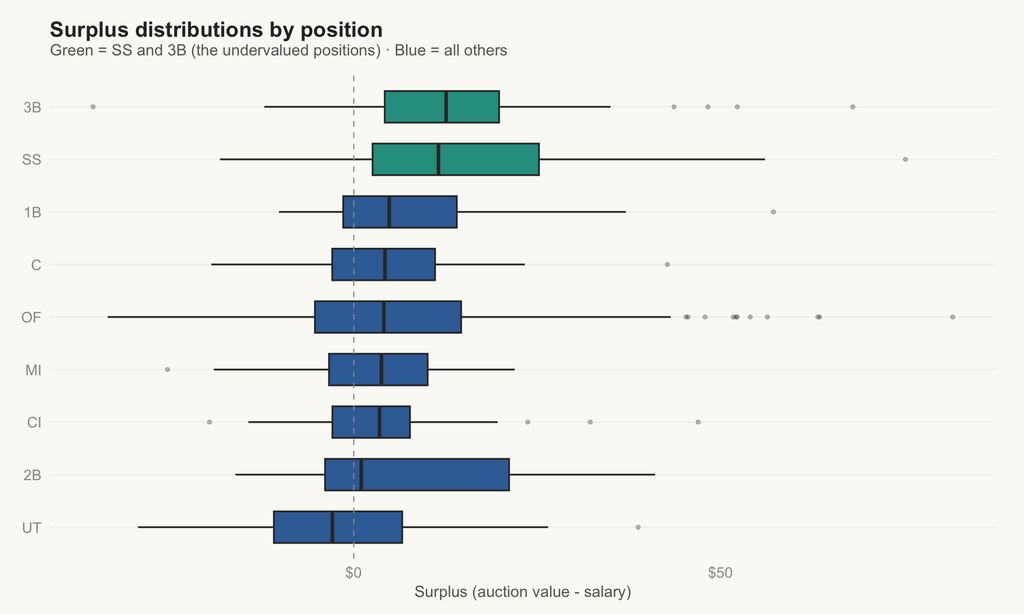

```r
# Show the surplus distribution per position (not just the mean)
all_val |>
  filter(!is.na(surplus), auction_value > 0, !is_pitcher, !is.na(position),
         position %in% pos_data$position) |>
  ggplot(aes(x = surplus, y = fct_reorder(position, surplus, .fun = median),
             fill = position %in% c("SS", "3B"))) +
  geom_boxplot(outlier.size = 1, outlier.alpha = 0.3, width = 0.6) +
  geom_vline(xintercept = 0, linetype = "dashed", color = pal$light, linewidth = 0.4) +
  scale_fill_manual(values = c("TRUE" = pal$accent, "FALSE" = pal$primary), guide = "none") +
  scale_x_continuous(labels = dollar_format(prefix = "$")) +
  labs(
    title = "Surplus distributions by position",
    subtitle = "Green = SS and 3B (the undervalued positions) · Blue = all others",
    x = "Surplus (auction value - salary)", y = NULL
  )
```

The boxplots show it’s not just the average — the entire SS and 3B distributions are shifted right. The median surplus is positive for both positions, while most other positions have a near-zero or negative median. The right tails are also longer, meaning these positions produce more extreme bargains.

# Principle 3: Ace Starters Are Underpriced Relative to Their Production

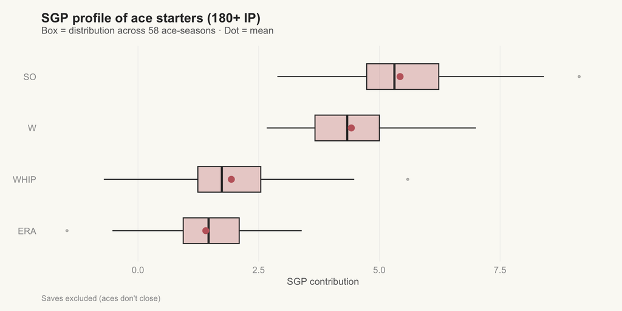

```r
aces <- all_val |>
  filter(is_pitcher, IP >= 180)

ace_profile <- aces |>
  summarise(
    across(c(sgp_W, sgp_SO, sgp_ERA, sgp_WHIP), mean),
    avg_auction = mean(auction_value),
    avg_production = mean(production_value),
    avg_salary = mean(salary),
    n = n()
  )

# Show ace SGP profile
ace_sgp <- aces |>
  select(player_name, year, sgp_W, sgp_SO, sgp_ERA, sgp_WHIP) |>
  pivot_longer(cols = starts_with("sgp_"), names_to = "category", values_to = "sgp") |>
  mutate(category = str_remove(category, "sgp_"))

ace_sgp |>
  ggplot(aes(x = sgp, y = fct_reorder(category, sgp))) +
  geom_boxplot(fill = pal$secondary, alpha = 0.3, outlier.size = 1, width = 0.5) +
  geom_point(stat = "summary", fun = mean, color = pal$secondary, size = 3) +
  labs(
    title = "SGP profile of ace starters (180+ IP)",
    subtitle = "Box = distribution across 58 ace-seasons · Dot = mean",
    x = "SGP contribution", y = NULL,
    caption = "Saves excluded (aces don't close)"
  ) +
  h_grid
```

An ace starter who pitches 180+ innings generates an average of **13.2 total SGP** — comparable to elite hitters. The breakdown: **5.4 SGP from strikeouts, 4.4 from wins, 1.9 from WHIP, and 1.4 from ERA**. They accumulate value across four categories simultaneously, making them one of the most efficient value sources in the league.

But here’s the key insight: aces average **$45 in production value** but only **$32 in auction value**. The $13 gap is the split-pool effect deflating pitcher prices. And their average salary? About **$25**. So even at auction value, aces generate roughly +$7 of surplus on average.

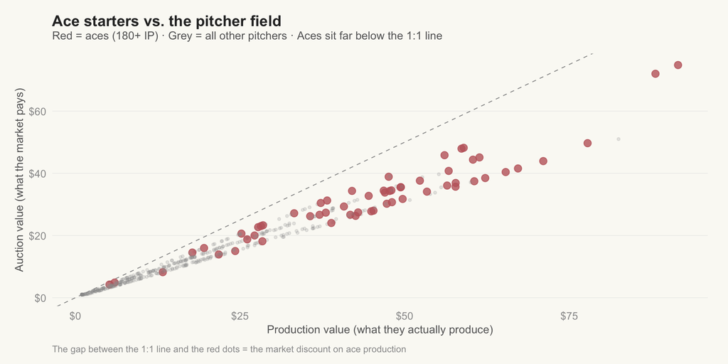

```r
# Show ace value vs the field
all_val |>
  filter(is_pitcher, auction_value > 0) |>
  mutate(is_ace = IP >= 180) |>
  ggplot(aes(x = production_value, y = auction_value,
             color = is_ace, alpha = is_ace, size = is_ace)) +
  geom_abline(slope = 1, intercept = 0, linetype = "dashed",
              color = pal$light, linewidth = 0.4) +
  geom_point() +
  scale_color_manual(values = c("FALSE" = pal$light, "TRUE" = pal$secondary)) +
  scale_alpha_manual(values = c("FALSE" = 0.2, "TRUE" = 0.8)) +
  scale_size_manual(values = c("FALSE" = 1, "TRUE" = 3)) +
  scale_x_continuous(labels = dollar_format(prefix = "$")) +
  scale_y_continuous(labels = dollar_format(prefix = "$")) +
  labs(
    title = "Ace starters vs. the pitcher field",
    subtitle = "Red = aces (180+ IP) · Grey = all other pitchers · Aces sit far below the 1:1 line",
    x = "Production value (what they actually produce)", y = "Auction value (what the market pays)",
    caption = "The gap between the 1:1 line and the red dots = the market discount on ace production"
  )
```

**The draft implication:** don’t be afraid to pay up for workhorse starters. The market systematically underprices them relative to their production because the split-pool method compresses pitcher values. An ace who costs $30 at auction is generating $45+ of production — that’s a better return than most hitters at the same price.

# Principle 4: Stolen Bases Are a Concentrated Weapon

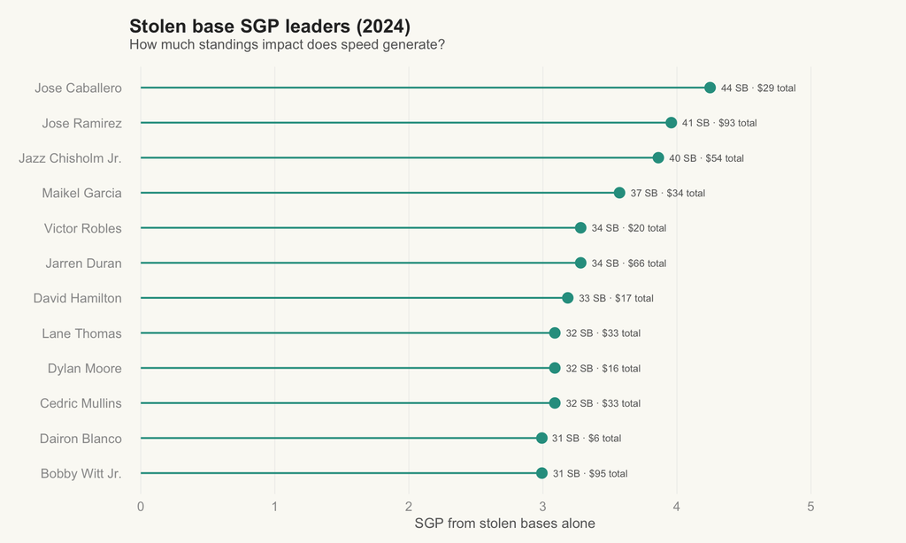

```r
sb_data <- all_val |>
  filter(!is_pitcher, auction_value > 0, year == 2024) |>
  mutate(sb_sgp_pct = sgp_SB / pmax(total_sgp, 0.1) * 100)

# Top SB contributors vs. their total value
sb_top <- sb_data |>
  filter(SB >= 20) |>
  arrange(desc(sgp_SB))

sb_top |>
  select(player_name, SB, sgp_SB, total_sgp, auction_value) |>
  mutate(sb_pct_of_value = sgp_SB / total_sgp * 100) |>
  head(12) |>
  ggplot(aes(x = sgp_SB, y = fct_reorder(player_name, sgp_SB))) +
  geom_segment(aes(x = 0, xend = sgp_SB,
                   yend = fct_reorder(player_name, sgp_SB)),
               color = pal$accent, linewidth = 0.7) +
  geom_point(color = pal$accent, size = 3.5) +
  geom_text(aes(label = paste0(round(SB), " SB · $", round(auction_value), " total")),
            hjust = -0.15, size = 2.8, color = pal$mid) +
  scale_x_continuous(expand = expansion(mult = c(0.02, 0.3))) +
  labs(
    title = "Stolen base SGP leaders (2024)",
    subtitle = "How much standings impact does speed generate?",
    x = "SGP from stolen bases alone", y = NULL
  ) +
  h_grid
```

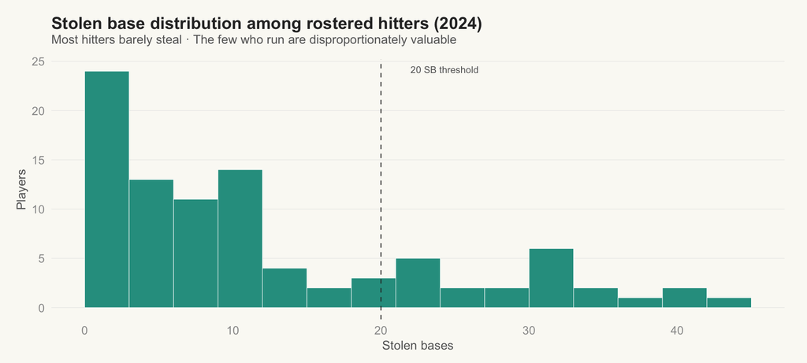

```r
# Show the SB distribution — how many players have meaningful SB?
all_val |>
  filter(!is_pitcher, auction_value > 0, year == 2024) |>
  ggplot(aes(x = SB)) +
  geom_histogram(binwidth = 3, boundary = 0, fill = pal$accent, color = "white", linewidth = 0.2) +
  geom_vline(xintercept = 20, linetype = "dashed", color = pal$text, linewidth = 0.4) +
  annotate("text", x = 22, y = Inf, label = "20 SB threshold", vjust = 2,
           color = pal$mid, size = 3, hjust = 0) +
  labs(
    title = "Stolen base distribution among rostered hitters (2024)",
    subtitle = "Most hitters barely steal · The few who run are disproportionately valuable",
    x = "Stolen bases", y = "Players"
  )
```

**The draft implication:** don’t treat stolen bases as a “nice to have.” Speed is one of the most scarce and valuable stat categories per unit. If you can lock up 2-3 players who steal 25+, you’ve likely secured a top-3 finish in the category, worth 8-10 standings points. The cost of missing on steals is steep because so few players contribute meaningfully.